# Unsupervised learning - clustering and dimension reduction

Allen Zhu

Fall 2019 9/18/19

# Lab Section

Download auto data from the *Statistical Learning* book website here: http://www-bcf.usc.edu/~gareth/ISL/data.html

Today, we are going over Hierarchical clustering, K-Means Clustering, PCA, and ICA.

## Homework

```r
data(iris)
```

0. Subset the Iris dataset to only include `Sepal.Length`, `Sepal.Width`, `Petal.Length`, and `Petal.Width`.

```r
vaars <- c('Sepal.Length', 'Sepal.Width', 'Petal.Length', 'Petal.Width')
new_iris <- iris[vaars]
```

1. Write out the Kmeans algorithm by hand, and run two iterations of it.

KMeans Skeleton Code: First determine the number of clusters that needs to be tested. Since there are three species of iris in the dataset, k will be set to 3.

If manually doing the algorithm by hand, my first 3 clusters will be 3 randomly selected points in the data set.

The euclidean distance is then calculated, and then the variables are sorted into the cluster that is closest to them (distance-wise).

The above step is repeated until the clustering becomes consistent, and subsequent iterations yield no changes.

```r
# Set seed so the randomly generated values can be replicated
set.seed(15)

random_int1 <- sample(1:150, 1)
random_int2 <- sample(1:150, 1)
random_int3 <- sample(1:150, 1)


# Using the randomly generated numbers to select datapoints from within the set
NI1 <- new_iris[random_int1,]
NI2 <- new_iris[random_int2,]
NI3 <- new_iris[random_int3,]
```

```r
# Copy of original data into a new variable
first_iris <- new_iris

# Calculate the euclidean distance for the three variables
first_iris <- mutate(first_iris, cluster1_1it = (NI1[,1]-Sepal.Length)**2+(NI1[,2]-Sepal.Width)**2 +(NI1[,3]-Petal.Length)**2 +(NI1[,4]-Petal.Width)**2)
first_iris <- mutate(first_iris, cluster2_1it = (NI2[,1]-Sepal.Length)**2+(NI2[,2]-Sepal.Width)**2 +(NI2[,3]-Petal.Length)**2 +(NI1[,4]-Petal.Width)**2)
first_iris <- mutate(first_iris, cluster3_1it = (NI3[,1]-Sepal.Length)**2+(NI3[,2]-Sepal.Width)**2 +(NI3[,3]-Petal.Length)**2 +(NI1[,4]-Petal.Width)**2)
```

```r
# Sorting all of the variables into a defined cluster based on their smallest euclidean value.
first_iris <- mutate(first_iris, first_it_cluster = ifelse((first_iris$cluster1_1it < first_iris$cluster3_1it & first_iris$cluster1_1it < first_iris$cluster2_1it) == TRUE, 1, ifelse((first_iris$cluster2_1it <  first_iris$cluster3_1it & first_iris$cluster2_1it < first_iris$cluster1_1it) == TRUE, 2, 3)))


# Counting the  number of samples in each cluster
length(first_iris$first_it_cluster[first_iris$first_it_cluster== 1])
```

```
## [1] 29
```

```r
length(first_iris$first_it_cluster[first_iris$first_it_cluster== 2])
```

```
## [1] 77
```

```r
length(first_iris$first_it_cluster[first_iris$first_it_cluster== 3])
```

```
## [1] 44
```

```r
# Filter the data frame based on clustering, and calculate the mean of each variable within each cluster.
t1 <- filter(first_iris, first_iris$first_it_cluster == 1)
t2 <- filter(first_iris, first_iris$first_it_cluster == 2)
t3 <- filter(first_iris, first_iris$first_it_cluster == 3)

# Finding out the new centroids for each cluster.
t1_sum <- t1[,1:4] %>% summarize_each(funs(mean))
t1_sum
```

| Sepal.Length | Sepal.Width | Petal.Length | Petal.Width |
| --- | --- | --- | --- |
| 5.6 | 3.113793 | 2.931034 | 0.8103448 |

```r
t2_sum <- t2[,1:4] %>% summarize_each(funs(mean))
t2_sum
```

| Sepal.Length | Sepal.Width | Petal.Length | Petal.Width |
| --- | --- | --- | --- |
| 6.485714 | 2.958442 | 5.218182 | 1.820779 |

```r
t3_sum <- t3[,1:4] %>% summarize_each(funs(mean))
t3_sum
```

| Sepal.Length | Sepal.Width | Petal.Length | Petal.Width |
| --- | --- | --- | --- |
| 4.879545 | 3.193182 | 1.747727 | 0.3681818 |

```r
first_iris
```

| Sepal.Length | Sepal.Width | Petal.Length | Petal.Width | cluster1_1it | cluster2_1it | cluster3_1it | first_it_cluster |
| --- | --- | --- | --- | --- | --- | --- | --- |
| 5.1 | 3.5 | 1.4 | 0.2 | 0.17 | 33.54 | 0.05 | 3 |
| 4.9 | 3.0 | 1.4 | 0.2 | 0.62 | 34.33 | 0.36 | 3 |
| 4.7 | 3.2 | 1.3 | 0.2 | 0.73 | 36.54 | 0.21 | 3 |
| 4.6 | 3.1 | 1.5 | 0.2 | 1.01 | 35.02 | 0.35 | 3 |
| 5.0 | 3.6 | 1.4 | 0.2 | 0.27 | 34.16 | 0.01 | 3 |
| 5.4 | 3.9 | 1.7 | 0.4 | 0.37 | 29.70 | 0.47 | 1 |
| 4.6 | 3.4 | 1.4 | 0.3 | 0.84 | 36.21 | 0.14 | 3 |
| 5.0 | 3.4 | 1.5 | 0.2 | 0.30 | 32.93 | 0.06 | 3 |
| 4.4 | 2.9 | 1.4 | 0.2 | 1.58 | 37.29 | 0.74 | 3 |
| 4.9 | 3.1 | 1.5 | 0.1 | 0.57 | 33.32 | 0.27 | 3 |

[output cut: 140 more lines]

```r
# Copy original iris data-frame for the second iteration of the data
second_iris <- new_iris

# Calculate the new euclidean distance using the calculated centroids from before
second_iris <- mutate(second_iris, cluster1_2it = (t1_sum[,1]-Sepal.Length)**2+(t1_sum[,2]-Sepal.Width)**2 +(t1_sum[,3]-Petal.Length)**2 +(t1_sum[,4]-Petal.Width)**2)
second_iris <- mutate(second_iris, cluster2_2it = (t2_sum[,1]-Sepal.Length)**2+(t2_sum[,2]-Sepal.Width)**2 +(t2_sum[,3]-Petal.Length)**2 +(t2_sum[,4]-Petal.Width)**2)
second_iris <- mutate(second_iris, cluster3_2it = (t3_sum[,1]-Sepal.Length)**2+(t3_sum[,2]-Sepal.Width)**2 +(t3_sum[,3]-Petal.Length)**2 +(t3_sum[,4]-Petal.Width)**2)


second_iris
```

| Sepal.Length | Sepal.Width | Petal.Length | Petal.Width | cluster1_2it | cluster2_2it | cluster3_2it |
| --- | --- | --- | --- | --- | --- | --- |
| 5.1 | 3.5 | 1.4 | 0.2 | 3.1157432 | 19.41892731 | 0.29193698 |
| 4.9 | 3.0 | 1.4 | 0.2 | 3.2195363 | 19.72165458 | 0.18693698 |
| 4.7 | 3.2 | 1.3 | 0.2 | 3.8502259 | 21.22620003 | 0.26102789 |
| 4.6 | 3.1 | 1.5 | 0.2 | 3.4205707 | 20.02775848 | 0.17648244 |
| 5.0 | 3.6 | 1.4 | 0.2 | 3.3129845 | 19.82438185 | 0.32920971 |
| 5.4 | 3.9 | 1.7 | 0.4 | 2.3419501 | 16.46152471 | 0.77375517 |
| 4.6 | 3.4 | 1.4 | 0.3 | 3.6864328 | 20.64217406 | 0.24648244 |
| 5.0 | 3.4 | 1.5 | 0.2 | 2.8622949 | 18.85412211 | 0.14693698 |
| 4.4 | 2.9 | 1.4 | 0.2 | 4.2022949 | 21.55905718 | 0.46511880 |
| 4.9 | 3.1 | 1.5 | 0.1 | 3.0426397 | 19.32048575 | 0.14239153 |

[output cut: 140 more lines]

```r
# Sort each sample into clusters based on their euclidean values
second_iris <- mutate(second_iris, second_it_cluster = ifelse((second_iris$cluster1_2it < second_iris$cluster3_2it & second_iris$cluster1_2it < second_iris$cluster2_2it) == TRUE, 1, ifelse((second_iris$cluster2_2it <  second_iris$cluster3_2it & second_iris$cluster2_2it < second_iris$cluster1_2it) == TRUE, 2, 3)))

second_iris
```

| Sepal.Length | Sepal.Width | Petal.Length | Petal.Width | cluster1_2it | cluster2_2it | cluster3_2it | second_it_cluster |
| --- | --- | --- | --- | --- | --- | --- | --- |
| 5.1 | 3.5 | 1.4 | 0.2 | 3.1157432 | 19.41892731 | 0.29193698 | 3 |
| 4.9 | 3.0 | 1.4 | 0.2 | 3.2195363 | 19.72165458 | 0.18693698 | 3 |
| 4.7 | 3.2 | 1.3 | 0.2 | 3.8502259 | 21.22620003 | 0.26102789 | 3 |
| 4.6 | 3.1 | 1.5 | 0.2 | 3.4205707 | 20.02775848 | 0.17648244 | 3 |
| 5.0 | 3.6 | 1.4 | 0.2 | 3.3129845 | 19.82438185 | 0.32920971 | 3 |
| 5.4 | 3.9 | 1.7 | 0.4 | 2.3419501 | 16.46152471 | 0.77375517 | 3 |
| 4.6 | 3.4 | 1.4 | 0.3 | 3.6864328 | 20.64217406 | 0.24648244 | 3 |
| 5.0 | 3.4 | 1.5 | 0.2 | 2.8622949 | 18.85412211 | 0.14693698 | 3 |
| 4.4 | 2.9 | 1.4 | 0.2 | 4.2022949 | 21.55905718 | 0.46511880 | 3 |
| 4.9 | 3.1 | 1.5 | 0.1 | 3.0426397 | 19.32048575 | 0.14239153 | 3 |

[output cut: 140 more lines]

```r
# Count the amount of subjects in each cluster
length(second_iris$second_it_cluster[second_iris$second_it_cluster== 1])
```

```
## [1] 22
```

```r
length(second_iris$second_it_cluster[second_iris$second_it_cluster== 2])
```

```
## [1] 78
```

```r
length(second_iris$second_it_cluster[second_iris$second_it_cluster== 3])
```

```
## [1] 50
```

```r
# Sort the subjects by their cluster, and calculate the new means for each cluster.
t21 <- filter(second_iris, second_iris$second_it_cluster == 1)

t22 <- filter(second_iris, second_iris$second_it_cluster == 2)

t23 <- filter(second_iris, second_iris$second_it_cluster == 3)


# Calculate new centroids again.
t21_sum <- t1[,1:4] %>% summarize_each(funs(mean))
t21_sum
```

| Sepal.Length | Sepal.Width | Petal.Length | Petal.Width |
| --- | --- | --- | --- |
| 5.6 | 3.113793 | 2.931034 | 0.8103448 |

```r
t22_sum <- t2[,1:4] %>% summarize_each(funs(mean))
t22_sum
```

| Sepal.Length | Sepal.Width | Petal.Length | Petal.Width |
| --- | --- | --- | --- |
| 6.485714 | 2.958442 | 5.218182 | 1.820779 |

```r
t23_sum <- t3[,1:4] %>% summarize_each(funs(mean))
t23_sum
```

| Sepal.Length | Sepal.Width | Petal.Length | Petal.Width |
| --- | --- | --- | --- |
| 4.879545 | 3.193182 | 1.747727 | 0.3681818 |

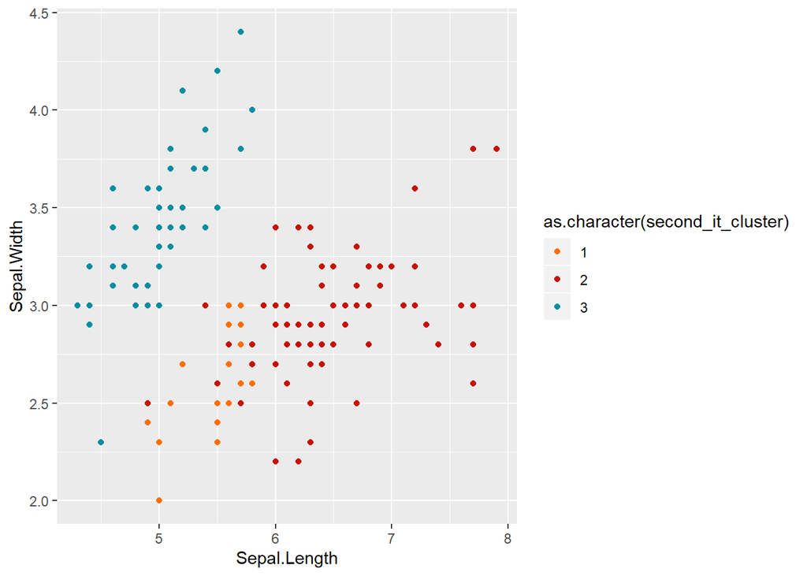

```r
# Visualize entire dataframe
ggplot(data = second_iris) + geom_point(aes(Sepal.Length, Sepal.Width, color = as.character(second_it_cluster)))+ ggsci::scale_color_futurama()
```